# Task 1: PCA (PELEGRI)

Create screeplot

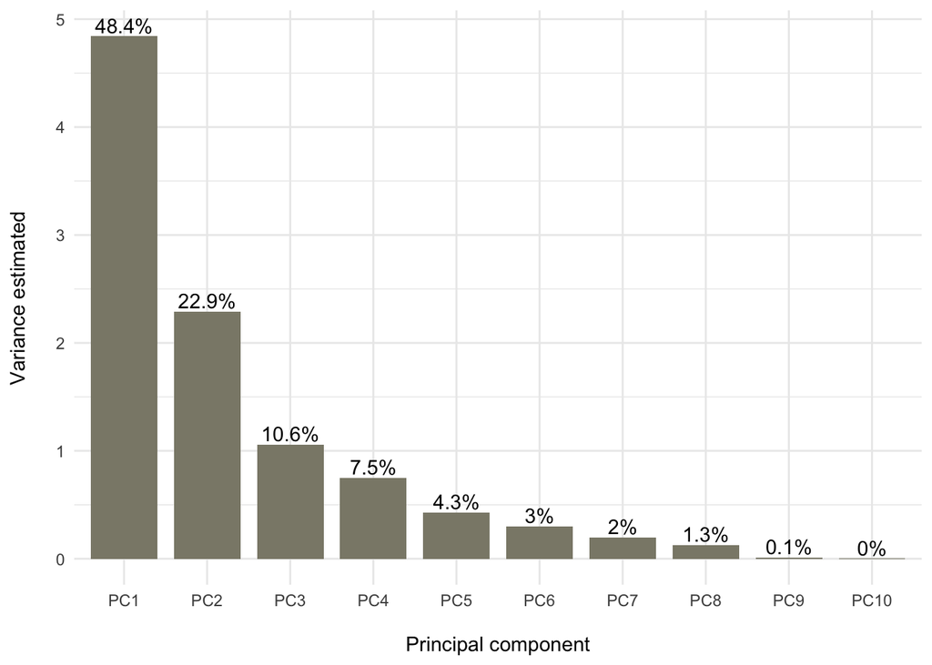

```r
sd_vec <- env_pca$sdev
var_vec <- sd_vec^2

pc_names <- colnames(env_pca$rotation)
pct_expl_df <- data.frame(v = var_vec,
                          pct_v = var_vec / sum(var_vec),
                          pc = fct_inorder(pc_names)) %>%
  mutate(pct_lbl = paste0(round(pct_v * 100, 1), '%'))

ggplot(data = pct_expl_df, aes(x = pc, y = v)) +
  geom_col(width = 0.8, fill = 'cornsilk4') +
  geom_text(aes(label = pct_lbl, vjust = -0.25, nudge_y = 0.0005)) +
  labs(x = "\nPrincipal component", y = "Variance estimated\n") +
  theme_minimal()
```

**Screeplot takeaways:**

- The first two PCAs capture ~70% of the variance.
- The most visible “elbows” in the screeplot occur after the third PCA or fourth PCA lis accounted for. In order to show the PCAs that occur before the “elbow” and a set of PCAs that add up to over 80%, an additional PCA plot is shown below comparing PCA 1 to PCA 3.

Create second biplot

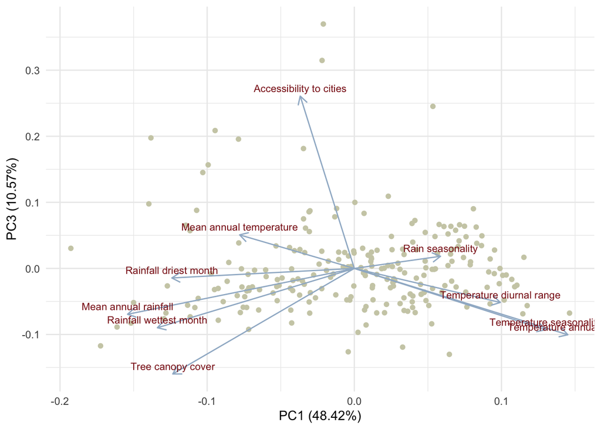

```r
autoplot(env_pca,
         data = env_sub_df,
         x = 1,
         y = 3,
         colour = "lightyellow3",
         loadings = TRUE,
         loadings.label = TRUE,
         loadings.colour = 'slategray3',
         loadings.label.colour = 'firebrick4',
         loadings.label.vjust = -0.6,
         loadings.label.size = 3) +
  theme_minimal()
```

**PCA plot 2 takeaways:**

- The variance of accessibility to cities is better represented by PCA 3.
- Accessibility of cities is quite uncorrelated with the other variables.
- The strongest correlation with accessibility to cities is mean annual temperature.